# Urgent Community Response

### Urgent Community Response

Urgent community response teams provide urgent care to people in their homes which helps to avoid hospital admissions and enable people to live independently for longer. Through these teams, older people and adults with complex health needs who urgently need care, can get fast access to a range of health and social care professionals within two hours. This includes access to physiotherapy and occupational therapy, medication prescribing and reviews, and help with staying well-fed and hydrated.

In 2021/22, providers, commissioners and systems have taken important actions to improve the capacity and responsiveness of existing UCR services to deliver care within two hours. In line with national roll-out of the two-hour standard by April 2022, integrated care systems (ICS) should provide a consistent service at scale, from 8am to 8pm, seven days a week (at a minimum) across the full geography of each ICS.

### Data Commentary

The **North East and Yorkshire** has the **highest** number of referrals at **9,345** in August and we can observe a special cause increasing trend. This number is not standardised by population and does not take into account the different population sizes of the regions. The average across the regions is 5,810.7.  
At the ICB level we can standardise to a rate by 10,000 population to give equitable comparison across ICBs.  
Within the North East and Yorkshire; **West Yorkshire** has the highest rate of referrals at **265.4** per 10,000 population and this rate is higher than the other ICBs in region and we can observe a static trend.  
The lowest rate within region is **South Yorkshire** with **101.6** referrals per 10,000 population.  
The **North East and Yorkshire** is performing at **81.4%** of urgent community referrals responded to within 2 hours, which is the **second lowest** of the regions in August, and we can observe this achievement rate to be a static trend.  
Within the North East and Yorkshire; **Humber And North Yorkshire** is performing the highest at **87.4%** of **1415** urgent referrals in August responded to with 2 hours and we can observe this achievement rate to be a decreasing trend.  
**South Yorkshire** has the lowest achievment at **70.4%** of **625** urgent referrals in August responded to with 2 hours and we can observe this achievement rate to be a special cause decreasing trend.  
The **North East and Yorkshire** conducted **19,255** care contacts related to urgent community response which is the middle number of the regions in August. This is not a standardised number and so does not take into account the relative size of the regions.  
Within the North East and Yorkshire; **North East And North Cumbria** had the highest rate of care contacts in August with **267.9** per 10,000 population which is statisically signifcantly higher than the average of **179** in the region.  
**South Yorkshire** had the lowest rate of care contacts in August with **102.9** per 10,000 population which is lower than the average of **179** in the region.

Urgent Community Response - data to 31 August 23

| Area | Referral numbers, rates and trends Referrals | Referral numbers, rates and trends Ref trend | Referral numbers, rates and trends Refs by pop | Referral numbers, rates and trends Chart | 2hr Response 2hr Achievement | 2hr Response Chart | 2hr Response 2hr Trend | Age Demographic **19-64**\|\|**65 Plus** | Care contacts Care Contacts | Care contacts Contacts by pop | Care contacts Chart | Care contacts Ave Contacts per referral |
| --- | --- | --- | --- | --- | --- | --- | --- | --- | --- | --- | --- | --- |
| East Of England | 6325 |  | 0.0 |  | 85.1% |  |  |  | 13505 | 0.0 |  | 2.1 |
| London | 3500 |  | 0.0 |  | 86.6% |  |  |  | 19260 | 0.0 |  | 5.5 |
| Midlands | 7295 |  | 0.0 |  | 87.4% |  |  |  | 21485 | 0.0 |  | 2.9 |
| North East And Yorkshire | 9345 |  | 0.0 |  | 81.4% |  |  |  | 19255 | 0.0 |  | 2.1 |
| North West | 4495 |  | 0.0 |  | 88.7% |  |  |  | 16480 | 0.0 |  | 3.7 |
| South East | 5730 |  | 0.0 |  | 84.7% |  |  |  | 24345 | 0.0 |  | 4.2 |
| South West | 3985 |  | 0.0 |  | 75.2% |  |  |  | 8110 | 0.0 |  | 2.0 |
| Humber And North Yorkshire | 1415 |  | 106.7 |  | 87.4% |  |  |  | 2110 | 116.9 |  | 1.5 |
| North East And North Cumbria | 4910 |  | 224.6 |  | 82.3% |  |  |  | 7965 | 267.9 |  | 1.6 |
| South Yorkshire | 625 |  | 101.6 |  | 70.4% |  |  |  | 2025 | 102.9 |  | 3.2 |
| West Yorkshire | 2395 |  | 265.4 |  | 79.0% |  |  |  | 7155 | 228.4 |  | 3.0 |

Data Source: Community Services Data Set (CSDS) - UDAL Extract - Current month is based on primary submission

**Referral Rates**

**Referral Rates**

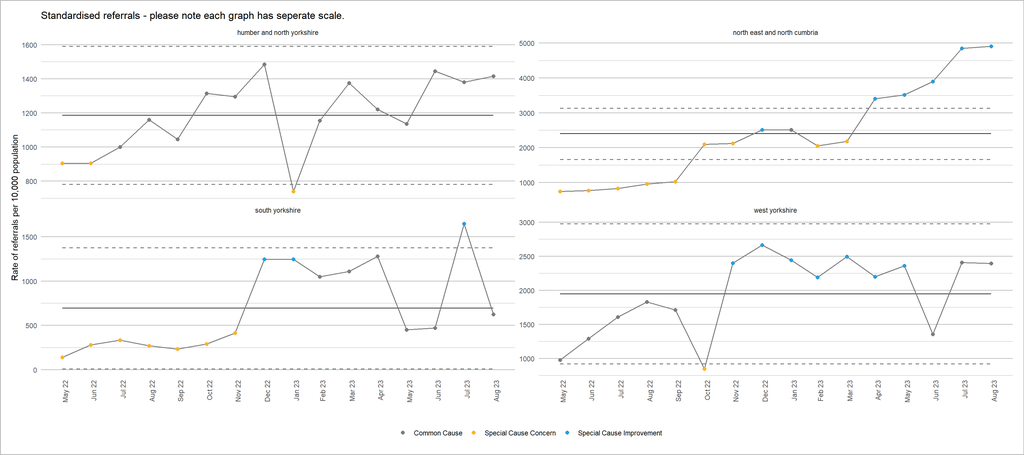

**2hr Achievement**

**2hr Achievement**

Statistical process control (SPC) charts showing achievement of 2hr standard response.  
**NOTE:** This metric can be confounded when there is a submission failure or data quality issue.

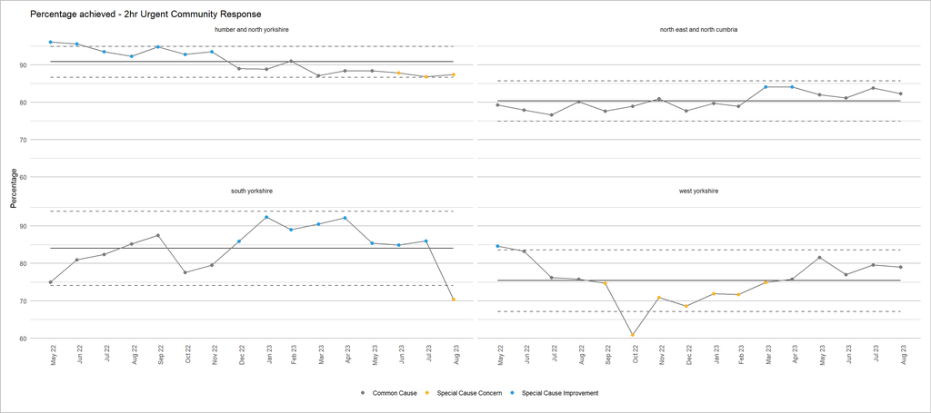

**Care Contacts**

**Care contacts**

Statistical process control (SPC) charts showing rate of care contacts per 10,000 population.  
**NOTE:** This metric can be confounded when there is a submission failure or data quality issue.

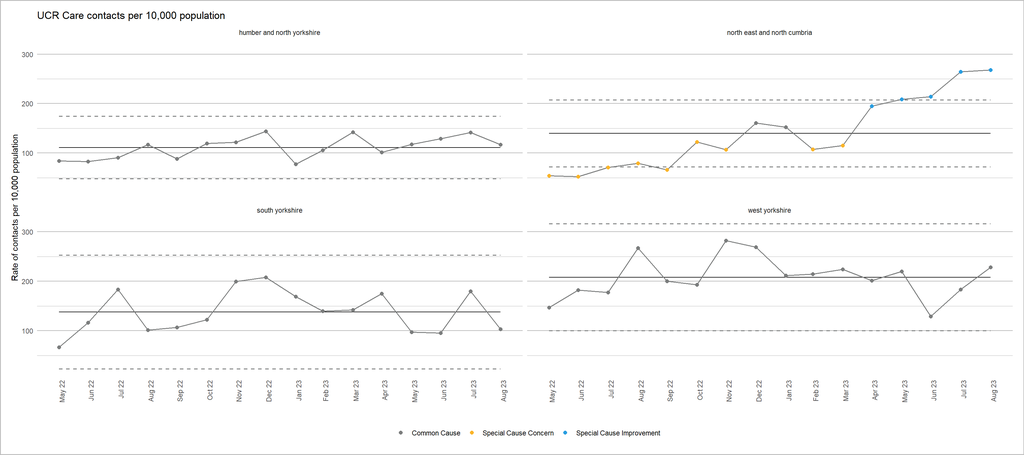

**Data note**

- Data taken from UDAL warehouse
- Collected from Community Services Data Set
- Trend commentary based on NHSE ‘Making Data Count’ statistical process control methodology
- Some number may appear not to add up, this may be due to small number supression that has been applied to the analysis
- **DATA QUALITY NOTE:** Data quality is poor with missing submissions and incomplete data. This affects both regional and ICB level data.
- NHS England’s Guidance Document for UCR can be found here [CSDS UCR Guidance](https://www.england.nhs.uk/publication/community-health-services-two-hour-urgent-community-response-standard-guidance/)
- NHS England’s UCR monitoring dashboard can be found here [UCR monitoring dashboard](https://app.powerbi.com/view?r=eyJrIjoiNjVhYTcxMjUtMDc3Ny00ZDJmLTk1ZWMtYjMzNDRjMmRkMTFiIiwidCI6IjM3YzM1NGIyLTg1YjAtNDdmNS1iMjIyLTA3YjQ4ZDc3NGVlMyJ9)

> **Contact**  
> **Simon Wellesley-Miller**  
> *Senior Analytical Manager*  
> *South West Intelligence and Insights Team*  
> Version 1.0 23 October 2023